# a3_task3_lory_salazar

Lory Salazar

11/9/2020

```r
urchins <- read.csv(here("data", "urchins.csv"))
```

## Section 1: Comparing purple and red urchins by size

In Section 1, I begin by exploring the urchins data and using different graphs and tables comparing the two species of urchins.

### Purple and red urchin graphs

First, I create a histogram and a box plot.

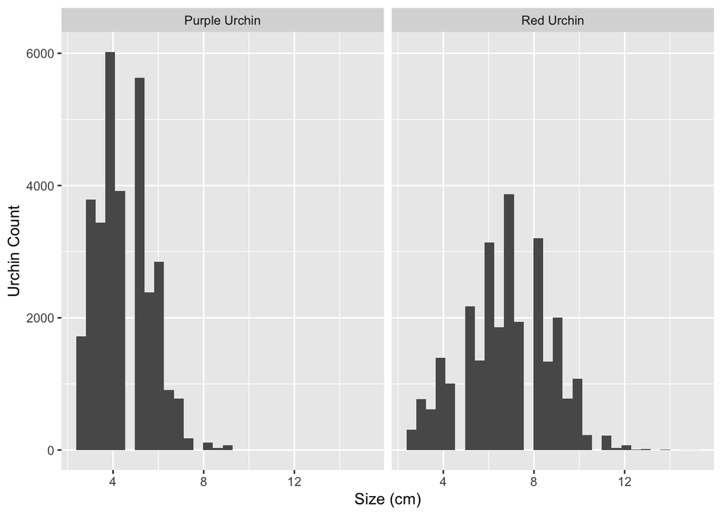

```r
ggplot(data = urchins, aes(x = SIZE)) +
  geom_histogram() +
  facet_wrap(~COMMON_NAME) +
  labs(x = "Size (cm)",
       y = "Urchin Count")
```

Based on these initial graphs, the red urchin sample appears to follow a fairly normal distribution. The purple urchin sample, meanwhile, is not normally distributed, and it is positively skewed, because we can see a tail in the positive direction of the x-axis. It appears that the samples might not have the same central tendencies. I would guess that the purple urchin sample has a lower measure of central tendency than red urchins.

Next, I create a box plot, which will help us to visualize the measures of central tendencies.

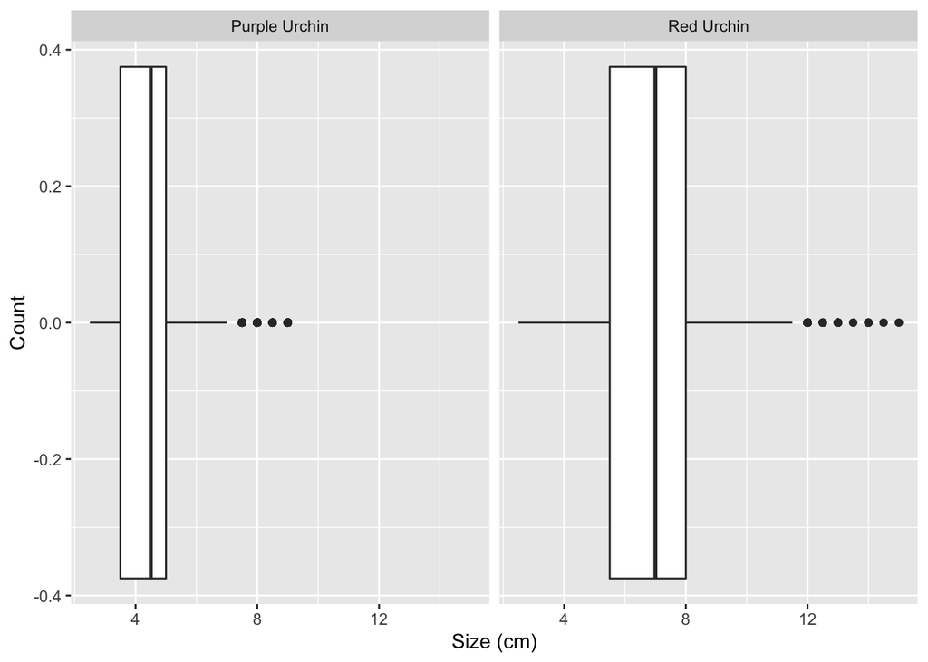

```r
ggplot(data = urchins, aes(x = SIZE)) +
  geom_boxplot() +
  facet_wrap(~COMMON_NAME) +
  labs(x = "Size (cm)",
       y = "Count")
```

### Descriptive table

After creating graphs to explore the data, I create a summary table containing mean, median, standard deviation, and sample size.

```r
urchins_stats <- urchins %>%
  group_by(COMMON_NAME) %>%
  summarize(mean_urchins = mean(SIZE),
            sd_urchins = sd(SIZE),
            med_urchins = median(SIZE),
            n_urchins = n())
urchins_stats
```

```
## # A tibble: 2 x 5
##   COMMON_NAME   mean_urchins sd_urchins med_urchins n_urchins
##   <chr>                <dbl>      <dbl>       <dbl>     <int>
## 1 Purple Urchin         4.47       1.18         4.5     31805
## 2 Red Urchin            6.78       1.89         7       27408
```

## Section 2: Exploring purple urchin counts by site and year

In section 2, I begin to explore site and year, which we previously ignored. I will be looking at the purple urchins in particular and creating both a summary table and graph to explore the data.

First, I make a subset of the data.

```r
purple_urchins <- urchins %>%
  filter(COMMON_NAME == "Purple Urchin") %>%
  mutate(date_updated = mdy(DATE)) %>%
  mutate(year = year(date_updated)) %>%
  mutate(site_full = case_when(
    SITE == "NAPL" ~ "Naples Reef",
    SITE == "AQUE" ~ "Arroyo Quemado Reef",
    SITE == "CARP" ~ "Carpinteria Reef",
    SITE == "MOHK" ~ "Mohawk Reef",
    SITE == "IVEE" ~ "Isla Vista Reef"
  ))
```

Next, I make a table to look at the purple urchins by site and year.

```r
purple_summary <- purple_urchins %>%
  count(site_full, year)
```

Last, I create a graph to show the counts of purple urchins recorded at each site over time, from 2008-2020.

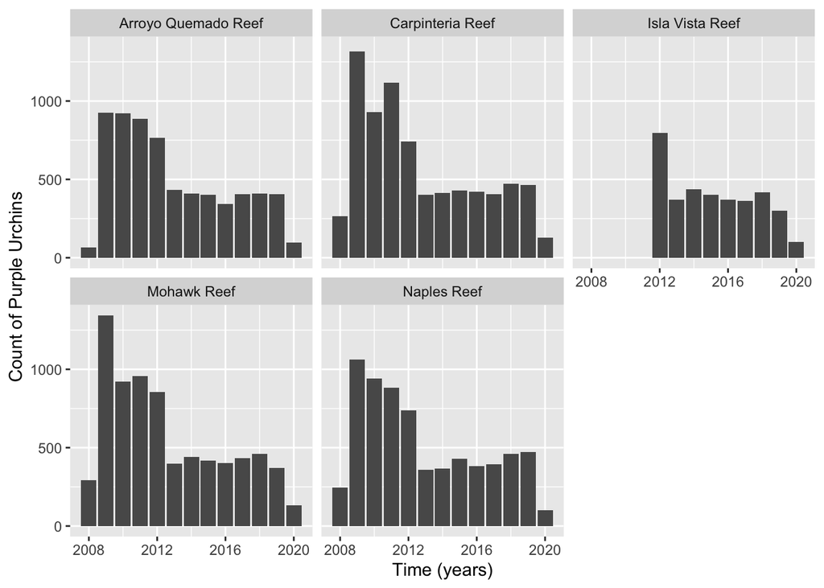

```r
ggplot(data = purple_summary, aes(x = year, y = n)) +
  geom_col() +
  facet_wrap(~site_full) +
  labs(x = "Time (years)",
       y = "Count of Purple Urchins")
```